# Modelo Lineal

Práctica Guiada

```r
library(tidyverse)
```

Para este ejercicio utilizaremos los datos provistos por Properati: https://www.properati.com.ar/data/

(Primero acondicionamos la base original, para quedarnos con una base más fácil de trabajar, y que contiene unicamente los datos interesantes. También eliminamos previamente los outliers)

```r
df <- read_rds('../fuentes/datos_properati.RDS')

df %>% sample_n(10)
```

| id | l3 | rooms | bathrooms | surface_total | surface_covered | price | property_type |
| --- | --- | --- | --- | --- | --- | --- | --- |
| edZMYiApijG+K5VE4X4ZVg== | Palermo | 2 | 1 | 35 | 35 | 110000 | Departamento |
| GTMBoOV0bBhwZFcfekpKRw== | Palermo | 2 | 1 | 31 | 31 | 120000 | Departamento |
| YDbAF9r/3F8hYmPCmz3m0Q== | Villa Crespo | 2 | 1 | 45 | 38 | 80000 | Departamento |
| 7dQAmYbspjlb1vnaOSiIfg== | Barrio Norte | 4 | 1 | 157 | 140 | 550000 | Departamento |
| XYeUmv1HsP5UwbYlOkE0JQ== | Floresta | 4 | 1 | 156 | 104 | 205000 | PH |
| i5TvbTLD6k0bqRXrj+vbdQ== | Belgrano | 1 | 1 | 36 | 32 | 120000 | Departamento |
| kWMc973B3CMlMdIEX03U3A== | Flores | 4 | 2 | 104 | 94 | 279900 | Departamento |
| IirnX/y4JcU/dAKyA9DOwQ== | Mataderos | 1 | 1 | 38 | 35 | 97625 | Departamento |
| 6h/izJOt4tK2bzTZUA8maA== | Palermo | 2 | 1 | 44 | 44 | 100000 | PH |
| HT4DBgm1KCRF9L+Mah6ONQ== | Flores | 3 | 1 | 73 | 61 | 130000 | PH |

### Primer modelo

```r
lm_fit <- lm(price~ l3+ rooms + bathrooms + surface_total + property_type,data = df)
```

```r
summary(lm_fit)
```

```
Call:
lm(formula = price ~ l3 + rooms + bathrooms + surface_total +
    property_type, data = df)

Residuals:
    Min      1Q  Median      3Q     Max
-432633  -34617   -2999   25213  583297

Coefficients:
                           Estimate Std. Error t value Pr(>|t|)
(Intercept)               -113646.5     4920.4 -23.097  < 2e-16 ***
l3Agronomía                 -7650.2     9089.3  -0.842 0.399975
l3Almagro                   -3300.7     4414.0  -0.748 0.454598
l3Balvanera                -21220.7     4677.0  -4.537 5.71e-06 ***
l3Barracas                  -8272.3     5498.9  -1.504 0.132499
l3Barrio Norte              53994.3     4539.3  11.895  < 2e-16 ***
l3Belgrano                  71899.8     4401.8  16.334  < 2e-16 ***
l3Boca                     -45747.9     7271.8  -6.291 3.18e-10 ***
l3Boedo                    -17793.3     5363.9  -3.317 0.000910 ***
l3Caballito                  6870.9     4420.2   1.554 0.120093
l3Catalinas                -97528.2    34489.4  -2.828 0.004689 **
l3Centro / Microcentro     -21833.7     6967.9  -3.133 0.001728 **
l3Chacarita                 12744.0     5445.6   2.340 0.019275 *
l3Coghlan                   37410.3     5613.6   6.664 2.69e-11 ***
l3Colegiales                30624.4     4949.3   6.188 6.16e-10 ***
l3Congreso                 -29213.2     5646.4  -5.174 2.30e-07 ***
l3Constitución             -44764.9     6496.3  -6.891 5.62e-12 ***
l3Flores                   -22964.2     4661.6  -4.926 8.41e-07 ***
l3Floresta                 -31310.0     5209.2  -6.010 1.86e-09 ***
l3Las Cañitas               91699.5     6046.1  15.167  < 2e-16 ***
l3Liniers                  -21533.4     5514.6  -3.905 9.44e-05 ***
l3Mataderos                -39034.8     5573.9  -7.003 2.54e-12 ***
l3Monserrat                -27085.3     5372.0  -5.042 4.63e-07 ***
l3Monte Castro             -10307.5     6114.1  -1.686 0.091832 .
l3Nuñez                     57485.1     4685.8  12.268  < 2e-16 ***
l3Once                     -24995.2     5606.2  -4.458 8.27e-06 ***
l3Palermo                   68847.6     4337.9  15.871  < 2e-16 ***
l3Parque Avellaneda        -36773.2     7808.1  -4.710 2.49e-06 ***
l3Parque Centenario        -10925.2     5155.1  -2.119 0.034071 *
l3Parque Chacabuco         -25904.2     5460.9  -4.744 2.11e-06 ***
```

[output cut: 23 more lines]

```
l3Villa Riachuelo          -41512.4    17645.2  -2.353 0.018646 *
l3Villa Santa Rita         -12362.7     6559.1  -1.885 0.059459 .
l3Villa Soldati           -127528.0    19467.4  -6.551 5.78e-11 ***
l3Villa Urquiza             28531.8     4540.9   6.283 3.35e-10 ***
rooms                        2959.2      434.8   6.806 1.02e-11 ***
bathrooms                   39771.6      651.8  61.014  < 2e-16 ***
surface_total                1934.2       12.7 152.267  < 2e-16 ***
property_typeDepartamento   90449.7     2251.4  40.175  < 2e-16 ***
property_typePH             38887.8     2332.4  16.673  < 2e-16 ***
---
Signif. codes:  0 ‘***’ 0.001 ‘**’ 0.01 ‘*’ 0.05 ‘.’ 0.1 ‘ ’ 1

Residual standard error: 68420 on 45842 degrees of freedom
Multiple R-squared:  0.7639,    Adjusted R-squared:  0.7636
F-statistic:  2431 on 61 and 45842 DF,  p-value: < 2.2e-16
```

> ¿ Qué pasó con las variables no numéricas? ¿Son significativos los estimadores? ¿cuales? ¿Cómo se leen los valores de los estimadores?

$$\Delta y = \beta_1 \Delta x$$

### Feature engineering.

Se denomina ingeniería de features a la construcción de nuevas variables a partir de las originales.

Por ejemplo, dado que muchos de los barrios no explican significativamente los cambios en los precios, no esta bueno conservarlos todos. A su vez, no sabemos respecto a qué barrio se compara.

Una solución puede ser agrupar los barrios en tres categorías respecto a su efecto en el precio:

- Alto
- Medio
- Bajo

En particular, podemos notar de esta primera regresión que algunos barrios tienen un efecto significativo en subir el valor de la propiedad, como Belgrano o Recoleta.

Para construir la nueva variable, podemos ver el precio promedio del metro cuadrado por barrio

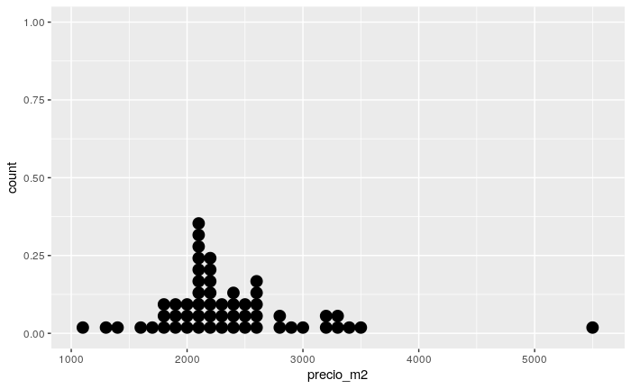

```r
df_barrios <- df %>%
  group_by(l3) %>%
  summarise(precio_m2 = mean(price/surface_total))

ggplot(df_barrios,aes(precio_m2)) +
  geom_dotplot(method = 'histodot', binwidth = 100)
```

```r
summary(df_barrios$precio_m2)
```

```
   Min. 1st Qu.  Median    Mean 3rd Qu.    Max.
   1093    2062    2204    2358    2579    5472
```

```r
df_barrios <- df_barrios %>%
  mutate(barrio= case_when(precio_m2<=2100 ~ 'bajo',
                           precio_m2>2100 & precio_m2<2400 ~ 'medio',
                          #between(precio_m2,2100,2400)~'medio', # Otra forma de escribirlo
                           precio_m2>=2400 ~ 'alto'))

df_barrios %>%
  sample_n(10)
```

| l3 | precio_m2 | barrio |
| --- | --- | --- |
| Mataderos | 1890.852 | bajo |
| Belgrano | 3316.104 | alto |
| Villa Real | 2090.086 | bajo |
| Parque Centenario | 2454.737 | alto |
| Flores | 2160.827 | medio |
| Villa Soldati | 1092.613 | bajo |
| Monte Castro | 2155.669 | medio |
| Parque Avellaneda | 1704.676 | bajo |
| Palermo | 3350.474 | alto |
| Recoleta | 3273.964 | alto |

Con esta nueva variable podemos modificar la tabla original.

```r
df <- df %>%
  left_join(df_barrios, by='l3')
```

y volvemos a calcular el modelo

```r
lm_fit <- lm(price~ barrio+ rooms + bathrooms + surface_total + property_type,data = df)

summary(lm_fit)
```

```
Call:
lm(formula = price ~ barrio + rooms + bathrooms + surface_total +
    property_type, data = df)

Residuals:
    Min      1Q  Median      3Q     Max
-503397  -37713   -8157   25437  722990

Coefficients:
                           Estimate Std. Error t value Pr(>|t|)
(Intercept)               -91188.38    2767.07  -32.95  < 2e-16 ***
barriobajo                -74794.81    1454.63  -51.42  < 2e-16 ***
barriomedio               -54930.91     936.27  -58.67  < 2e-16 ***
rooms                      -2793.72     482.48   -5.79 7.07e-09 ***
bathrooms                  44048.54     731.31   60.23  < 2e-16 ***
surface_total               2109.92      14.16  149.05  < 2e-16 ***
property_typeDepartamento 106723.05    2493.37   42.80  < 2e-16 ***
property_typePH            46226.80    2620.10   17.64  < 2e-16 ***
---
Signif. codes:  0 ‘***’ 0.001 ‘**’ 0.01 ‘*’ 0.05 ‘.’ 0.1 ‘ ’ 1

Residual standard error: 77360 on 45896 degrees of freedom
Multiple R-squared:  0.6978,    Adjusted R-squared:  0.6977
F-statistic: 1.514e+04 on 7 and 45896 DF,  p-value: < 2.2e-16
```

Si queremos que compare contra ‘barrio medio’ podemos convertir la variable en factor y explicitar los niveles

```r
df <- df %>%
  mutate(barrio = factor(barrio, levels = c('medio', 'alto','bajo')))

lm_fit <- lm(price~ barrio+ rooms + bathrooms + surface_total + property_type,data = df)

summary(lm_fit)
```

```
Call:
lm(formula = price ~ barrio + rooms + bathrooms + surface_total +
    property_type, data = df)

Residuals:
    Min      1Q  Median      3Q     Max
-503397  -37713   -8157   25437  722990

Coefficients:
                            Estimate Std. Error t value Pr(>|t|)
(Intercept)               -146119.29    2747.61  -53.18  < 2e-16 ***
barrioalto                  54930.91     936.27   58.67  < 2e-16 ***
barriobajo                 -19863.90    1585.84  -12.53  < 2e-16 ***
rooms                       -2793.72     482.48   -5.79 7.07e-09 ***
bathrooms                   44048.54     731.31   60.23  < 2e-16 ***
surface_total                2109.92      14.16  149.05  < 2e-16 ***
property_typeDepartamento  106723.05    2493.37   42.80  < 2e-16 ***
property_typePH             46226.80    2620.10   17.64  < 2e-16 ***
---
Signif. codes:  0 ‘***’ 0.001 ‘**’ 0.01 ‘*’ 0.05 ‘.’ 0.1 ‘ ’ 1

Residual standard error: 77360 on 45896 degrees of freedom
Multiple R-squared:  0.6978,    Adjusted R-squared:  0.6977
F-statistic: 1.514e+04 on 7 and 45896 DF,  p-value: < 2.2e-16
```

> Cuál es el mejor modelo? Con los barrios colapsados en tres niveles, o con todos los barrios?

### Transformaciones log.

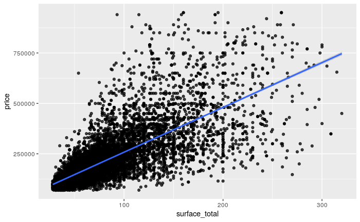

```r
df %>%
  sample_n(10000) %>%
ggplot(., aes(surface_total, price))+
  geom_point(alpha=0.75)+
  geom_smooth(method = 'lm')
```

Nuestros datos no tienen varianza constante, tienen *heterocedasticidad*. Que la varianza sea constante es uno de los supestos del modelo lineal.

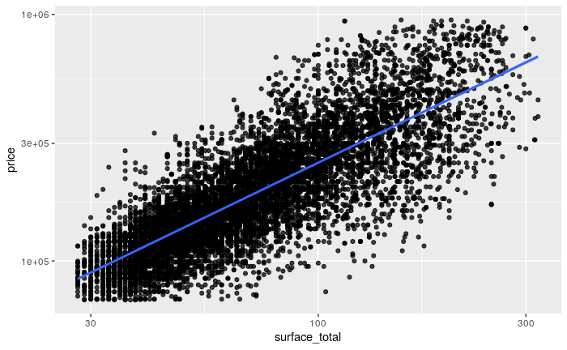

```r
df %>%
  sample_n(10000) %>%
ggplot(., aes(surface_total, price))+
  geom_point(alpha=0.75)+
  geom_smooth(method = 'lm')+
  scale_y_log10()+
  scale_x_log10()
```

La transformación logarítmica parece ser una buena idea para nuestros datos

```r
lm_fit <- lm(log(price)~ barrio+ rooms + bathrooms + log(surface_total) + property_type,data = df)

summary(lm_fit)
```

```
Call:
lm(formula = log(price) ~ barrio + rooms + bathrooms + log(surface_total) +
    property_type, data = df)

Residuals:
    Min      1Q  Median      3Q     Max
-1.3017 -0.1615 -0.0051  0.1486  1.4464

Coefficients:
                           Estimate Std. Error t value Pr(>|t|)
(Intercept)                8.082582   0.018153 445.255  < 2e-16 ***
barrioalto                 0.256069   0.003035  84.366  < 2e-16 ***
barriobajo                -0.130626   0.005141 -25.409  < 2e-16 ***
rooms                     -0.016385   0.001712  -9.569  < 2e-16 ***
bathrooms                  0.120528   0.002327  51.791  < 2e-16 ***
log(surface_total)         0.833111   0.004455 187.000  < 2e-16 ***
property_typeDepartamento  0.220169   0.007871  27.974  < 2e-16 ***
property_typePH            0.022008   0.008358   2.633  0.00846 **
---
Signif. codes:  0 ‘***’ 0.001 ‘**’ 0.01 ‘*’ 0.05 ‘.’ 0.1 ‘ ’ 1

Residual standard error: 0.2508 on 45896 degrees of freedom
Multiple R-squared:  0.7833,    Adjusted R-squared:  0.7833
F-statistic: 2.371e+04 on 7 and 45896 DF,  p-value: < 2.2e-16
```

- El $R^2$ pasó de 0.6977 a 0.7833!!
- Cómo se interpretan ahora los nuevos parámetros?

| Modelo | Variable Dependiente | Variable Independiente | Interpretación $\beta_1$ |
| --- | --- | --- | --- |
| Nivel-Nivel | $y$ | $x$ | $\Delta y = \beta_1 \Delta x$ |
| Nivel-log | $y$ | $log(x)$ | $\Delta y = (\beta_1/100)\% \Delta x$ |
| Log-nivel | $log(y)$ | $x$ | $\% \Delta y = (100 \beta_1) \Delta x$ |
| Log-log | $log(y)$ | $log(x)$ | $\% \Delta y = \beta_1 \% \Delta x$ |

### Predicciones

Para predecir un nuevo caso, podemos construir un dataframe con las variables. Por ejemplo

```r
caso_nuevo <- tibble(barrio='alto',
       rooms=2,
       bathrooms=2,
       property_type='Departamento',
       surface_total=78)

predict(lm_fit,newdata = caso_nuevo)
```

```
       1
12.39673
```

Pero debemos recordar que este es el valor del logarítmo del percio. Por lo tanto tenemos que realizar el caminio inverso con la función `exp`

```r
exp(predict(lm_fit,caso_nuevo))
```

```
       1
242008.3
```

### Para seguir practicando

Un problema de lo que vimos en esta práctica es que las salidas de `summary(lm_fit)` es una impresión en la consola. Es muy difícil seguir trabajando con esos resultados. Para resolver esto hay un par de librerías que incorporan el modelado lineal al flujo del tidyverse:

- [Broom](https://cran.r-project.org/web/packages/broom/vignettes/broom.html)
- [Modelr](https://modelr.tidyverse.org/)